# SLF_Project_TemplateNotebook

## EDA

- It is a good idea to explore the data once again after manipulating it.

```python
pd.set_option(
    "display.float_format", lambda x: "%.3f" % x)
df.describe(include="all").T
```

|  | count | unique | top | freq | mean | std | min | 25% | 50% | 75% | max |
| --- | --- | --- | --- | --- | --- | --- | --- | --- | --- | --- | --- |
| brand_name | 3571 | 34 | Others | 509 | NaN | NaN | NaN | NaN | NaN | NaN | NaN |
| os | 3571 | 4 | Android | 3246 | NaN | NaN | NaN | NaN | NaN | NaN | NaN |
| screen_size | 3571.000 | NaN | NaN | NaN | 14.522 | 4.166 | 6.985 | 12.700 | 13.490 | 16.510 | 22.225 |
| main_camera_mp | 3571.000 | NaN | NaN | NaN | 9.300 | 4.531 | 0.080 | 5.000 | 8.000 | 13.000 | 25.000 |
| selfie_camera_mp | 3571.000 | NaN | NaN | NaN | 5.972 | 5.287 | 0.300 | 2.000 | 5.000 | 8.000 | 17.000 |
| int_memory | 3571.000 | NaN | NaN | NaN | 44.583 | 38.939 | 0.005 | 16.000 | 32.000 | 64.000 | 136.000 |
| ram | 3571.000 | NaN | NaN | NaN | 4.000 | 0.000 | 4.000 | 4.000 | 4.000 | 4.000 | 4.000 |
| battery | 3571.000 | NaN | NaN | NaN | 3042.193 | 1272.573 | 80.000 | 2100.000 | 3000.000 | 4000.000 | 6850.000 |
| weight | 3571.000 | NaN | NaN | NaN | 164.416 | 41.098 | 74.000 | 140.000 | 159.000 | 184.000 | 250.000 |
| release_year | 3571.000 | NaN | NaN | NaN | 2015.965 | 2.292 | 2013.000 | 2014.000 | 2016.000 | 2018.000 | 2020.000 |
| days_used | 3571.000 | NaN | NaN | NaN | 675.391 | 248.641 | 91.000 | 536.000 | 690.000 | 872.000 | 1094.000 |
| 4_5g | 3571 | 2 | 4g | 2359 | NaN | NaN | NaN | NaN | NaN | NaN | NaN |
| log_new_price | 3571.000 | NaN | NaN | NaN | 5.220 | 0.719 | 2.212 | 4.789 | 5.246 | 5.677 | 7.848 |
| log_used_price | 3571.000 | NaN | NaN | NaN | 4.342 | 0.832 | 0.920 | 3.811 | 4.325 | 4.836 | 7.558 |

```python
df.shape
```

```
(3571, 14)
```

Since we did not delete missing values and outliers, the data shape is the same but one column has been removed

### All plots show us that their skewness is less than before

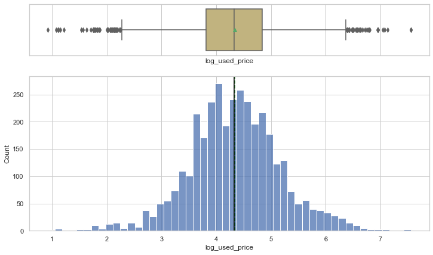

```python
histogram_boxplot(df, "log_used_price")# Average used_price droped from 109.880 euro to 95.5
```

- its skweness is less than before

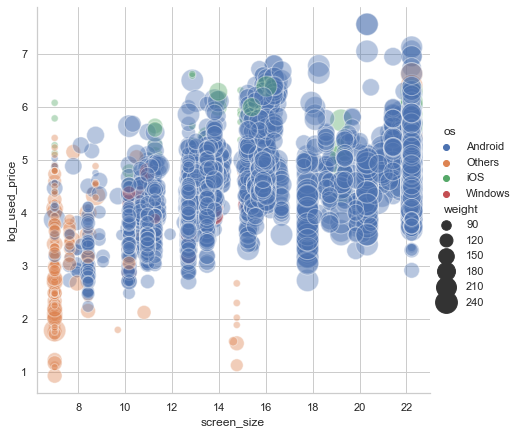

```python
sns.relplot(data = df, x='screen_size', y='log_used_price', hue='os',size='weight',sizes= (50,500),
            alpha= 0.4,height= 6 );
```

it seems that heavy cell phones have a bigger screen and bigger screen does affect the price.

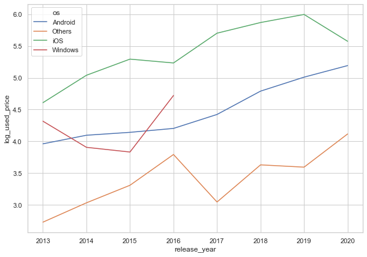

```python
plt.figure(figsize=(10,7))
sns.lineplot(data=df, x="release_year", y="log_used_price", hue="os", ci=None);
```

the log_used_price of ios and Android were going up till 2019 but then ios is coming down. Also, the Others os are going up and Windows stop producing in 2016. Totally it is acceptable that the recently released cell phone has a price higher than the old released..

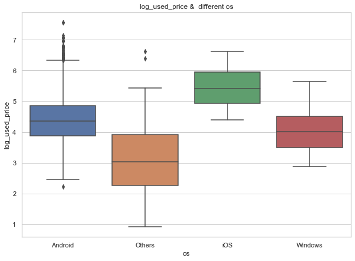

```python
plt.figure(figsize=(10,7))

ax = sns.boxplot(x="os", y="log_used_price",data=df)
plt.title("log_used_price &  different os");
```

after dealing with missing values and outliers they seem better than before. their skewness is less with lower outliers which are not shaped the distribution.

## QUESTIONS

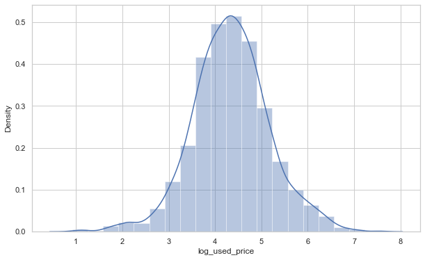

```python
#What does the distribution of used phone prices look like?
plt.figure(figsize=(10,6))
sns.distplot(df.log_used_price,color="b",bins=20);
```

```python
#What percentage of the used phone market is dominated by Android devices?

(df['os'].value_counts()/df['os'].value_counts().sum())[0]
```

```
0.9089890786894428
```

around 90% of the used phone market is dominated by Android devices and as you can see it doesn't change

```python
#How does the amount of RAM vary with the brand?

df.groupby('brand_name')['ram'].mean().sort_values(ascending= False)
```

```
brand_name
Acer         4.000
Panasonic    4.000
Microsoft    4.000
Motorola     4.000
Nokia        4.000
OnePlus      4.000
Oppo         4.000
Others       4.000
Realme       4.000
Alcatel      4.000
Samsung      4.000
Sony         4.000
Spice        4.000
Vivo         4.000
XOLO         4.000
Xiaomi       4.000
Micromax     4.000
Meizu        4.000
Lenovo       4.000
Lava         4.000
LG           4.000
Karbonn      4.000
Infinix      4.000
Huawei       4.000
Honor        4.000
HTC          4.000
Google       4.000
Gionee       4.000
Coolpad      4.000
Celkon       4.000
BlackBerry   4.000
Asus         4.000
Apple        4.000
ZTE          4.000
Name: ram, dtype: float64
```

**after dealing with outliers and missing values we just have one value in ram column so, I think it is better to delete this column**

```python
#How does the weight vary for phones offering large batteries (more than 4500 mAh)?

#I started with filtering the data base on mAh>4500 and get their means
df0=df[df['battery']>4500]
df0.groupby('weight')['battery'].mean()
```

```
weight
74.000    5884.000
118.000   4800.000
130.400   6850.000
145.000   4850.000
147.500   5550.000
            ...
238.000   6850.000
239.000   5000.000
240.000   6000.000
241.000   5000.000
250.000   6067.047
Name: battery, Length: 69, dtype: float64
```

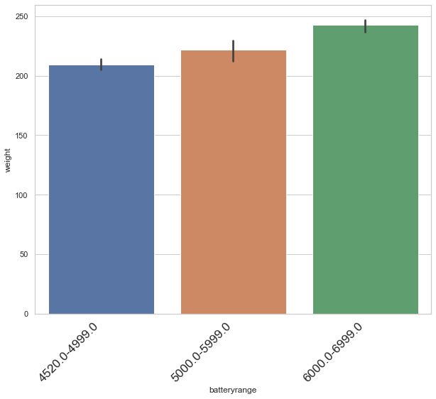

```python
# for best underestanding I categorized battery column to 3 groups and then got a bar plot
bins = [4000.0, 5000.0, 6000.0, 7000.0]
labels = ['4520.0-4999.0','5000.0-5999.0','6000.0-6999.0']
df0['batteryrange'] = pd.cut(df0.battery,bins, labels = labels,include_lowest = True)
plt.figure(figsize=(10,8))
chart=sns.barplot(data = df0, x='batteryrange',y='weight',)
chart.set_xticklabels(
    chart.get_xticklabels(),
    rotation=45,
    horizontalalignment='right',
    fontweight='light',
    fontsize='x-large');
```

like before cellphones with highest weight have larger batteries

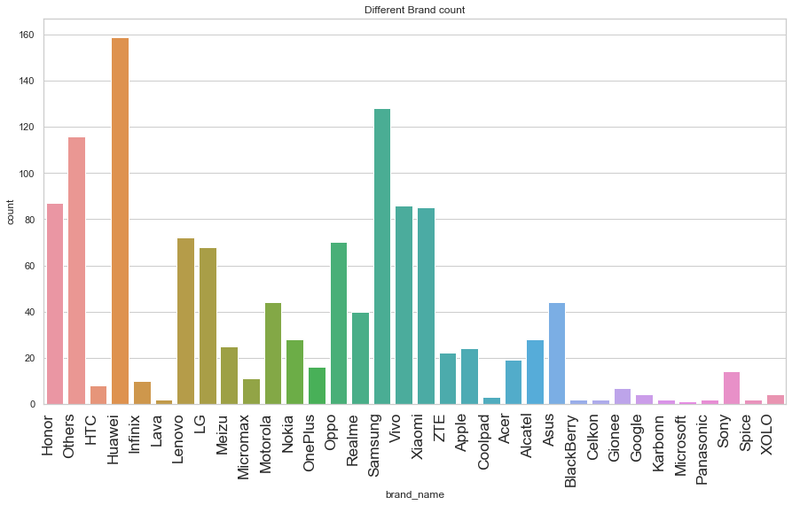

```python
#How many phones are available across different brands with a screen size larger than 6 inches?

#since our valuse in screen_size column is in centimeters, I needed to convert inche to cm : 6 inches is equal to 15.24 cm

df3=df[df['screen_size']>15.24]
plt.figure(figsize=(15,8))
c=sns.countplot(data = df3, x='brand_name')
c.set_xticklabels(
    c.get_xticklabels(),
    rotation=90,
    horizontalalignment='right',
    fontweight='light',
    fontsize='x-large')
plt.title("Different Brand count")
plt.show();
```

```python
df3['brand_name'].value_counts()
```

```
Huawei        159
Samsung       128
Others        116
Honor          87
Vivo           86
Xiaomi         85
Lenovo         72
Oppo           70
LG             68
Motorola       44
Asus           44
Realme         40
Alcatel        28
Nokia          28
Meizu          25
Apple          24
ZTE            22
Acer           19
OnePlus        16
Sony           14
Micromax       11
Infinix        10
HTC             8
Gionee          7
XOLO            4
Google          4
Coolpad         3
Karbonn         2
Spice           2
Lava            2
Celkon          2
Panasonic       2
BlackBerry      2
Microsoft       1
Name: brand_name, dtype: int64
```

##### Again between all brands, Huawei and Samsung cell phones are more than other brands which have screen sizes bigger than 6 inches (159 and 128) also, we have `Other` category which is located after them(116)

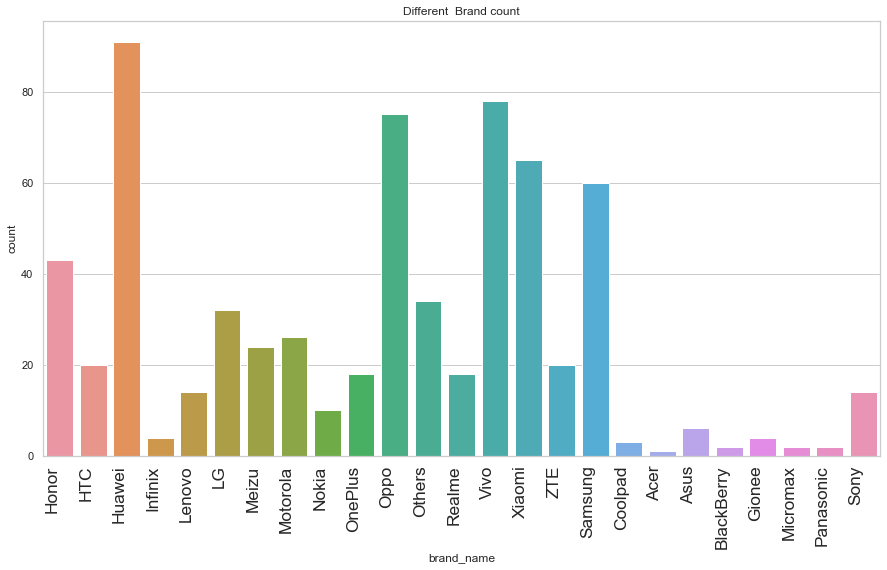

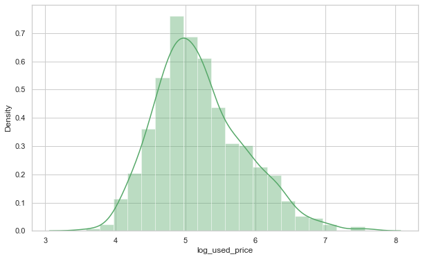

```python
# What is the distribution of budget phones offering greater than 8MP selfie cameras across brands?

df4 = df[(df["selfie_camera_mp"] > 8.0) & (df["log_used_price"] < 300.0)]# I assumed prices less than 300 Euros as a low-cost(budget)phone

plt.figure(figsize=(15,8))
c=sns.countplot(data = df4, x='brand_name')
c.set_xticklabels(
    c.get_xticklabels(),
    rotation=90,
    horizontalalignment='right',
    fontweight='light',
    fontsize='x-large')
plt.title("Different  Brand count")

plt.figure(figsize=(10,6))
sns.distplot(df4.log_used_price
             ,color="g",bins=20);
```

the distribution of budget phones offering greater than 8MP selfie cameras across brands is normal in compere to previews plot it is not very skewed to the right

```python
#Which attributes are highly correlated with the used phone price?
df.corr()
```

|  | screen_size | main_camera_mp | selfie_camera_mp | int_memory | ram | battery | weight | release_year | days_used | log_new_price | log_used_price |
| --- | --- | --- | --- | --- | --- | --- | --- | --- | --- | --- | --- |
| screen_size | 1.000 | 0.190 | 0.441 | 0.357 | NaN | 0.754 | 0.716 | 0.503 | -0.436 | 0.448 | 0.544 |
| main_camera_mp | 0.190 | 1.000 | 0.447 | 0.140 | NaN | 0.240 | 0.060 | 0.310 | -0.108 | 0.534 | 0.499 |
| selfie_camera_mp | 0.441 | 0.447 | 1.000 | 0.612 | NaN | 0.409 | 0.202 | 0.757 | -0.576 | 0.482 | 0.621 |
| int_memory | 0.357 | 0.140 | 0.612 | 1.000 | NaN | 0.314 | 0.201 | 0.520 | -0.471 | 0.362 | 0.480 |
| ram | NaN | NaN | NaN | NaN | NaN | NaN | NaN | NaN | NaN | NaN | NaN |
| battery | 0.754 | 0.240 | 0.409 | 0.314 | NaN | 1.000 | 0.753 | 0.490 | -0.376 | 0.453 | 0.526 |
| weight | 0.716 | 0.060 | 0.202 | 0.201 | NaN | 0.753 | 1.000 | 0.257 | -0.216 | 0.379 | 0.406 |
| release_year | 0.503 | 0.310 | 0.757 | 0.520 | NaN | 0.490 | 0.257 | 1.000 | -0.749 | 0.293 | 0.518 |
| days_used | -0.436 | -0.108 | -0.576 | -0.471 | NaN | -0.376 | -0.216 | -0.749 | 1.000 | -0.202 | -0.521 |
| log_new_price | 0.448 | 0.534 | 0.482 | 0.362 | NaN | 0.453 | 0.379 | 0.293 | -0.202 | 1.000 | 0.935 |
| log_used_price | 0.544 | 0.499 | 0.621 | 0.480 | NaN | 0.526 | 0.406 | 0.518 | -0.521 | 0.935 | 1.000 |

#### still the `log_new_price` column is highly correlated with the used phone price (with corr-score of 0.93)

## Building a Linear Regression model

```python
#Create Dummy Variables for 3 columns

df1 = pd.get_dummies(df, columns=['4_5g','os','brand_name'])
```

```python
df1.columns
```

```
Index(['screen_size', 'main_camera_mp', 'selfie_camera_mp', 'int_memory',
       'ram', 'battery', 'weight', 'release_year', 'days_used',
       'log_new_price', 'log_used_price', '4_5g_4g', '4_5g_other',
       'os_Android', 'os_Others', 'os_Windows', 'os_iOS', 'brand_name_Acer',
       'brand_name_Alcatel', 'brand_name_Apple', 'brand_name_Asus',
       'brand_name_BlackBerry', 'brand_name_Celkon', 'brand_name_Coolpad',
       'brand_name_Gionee', 'brand_name_Google', 'brand_name_HTC',
       'brand_name_Honor', 'brand_name_Huawei', 'brand_name_Infinix',
       'brand_name_Karbonn', 'brand_name_LG', 'brand_name_Lava',
       'brand_name_Lenovo', 'brand_name_Meizu', 'brand_name_Micromax',
       'brand_name_Microsoft', 'brand_name_Motorola', 'brand_name_Nokia',
       'brand_name_OnePlus', 'brand_name_Oppo', 'brand_name_Others',
       'brand_name_Panasonic', 'brand_name_Realme', 'brand_name_Samsung',
       'brand_name_Sony', 'brand_name_Spice', 'brand_name_Vivo',
       'brand_name_XOLO', 'brand_name_Xiaomi', 'brand_name_ZTE'],
      dtype='object')
```

### since `ram` column has just one value(4.000) I will delete it

```python
#split the data

# independent variables
x = df1.drop(['log_used_price','4_5g_other','os_Others','brand_name_Xiaomi','ram'], axis=1)

# the dependent variable
y = df1[['log_used_price']]
```

```python
# Split X and y into training and test set in 70:30 ratio

x_train, x_test, y_train, y_test = train_test_split(x, y, test_size=0.30, random_state=1)
```

```python
print("Number of rows in train data =", x_train.shape[0])
print("Number of rows in test data =", x_test.shape[0])
```

```
Number of rows in train data = 2499
Number of rows in test data = 1072
```

### Fit Linear Model

```python
linearregression = LinearRegression()
linearregression.fit(x_train, y_train)
```

```
LinearRegression()
```

Here are the coefficients for each variable and the intercept

```python
coef_df = pd.DataFrame(
    np.append(linearregression.coef_, linearregression.intercept_),
    index=x_train.columns.tolist() + ["Intercept"],
    columns=["Coefficients"],
)

coef_df
```

|  | Coefficients |
| --- | --- |
| screen_size | 0.002 |
| main_camera_mp | -0.001 |
| selfie_camera_mp | 0.001 |
| int_memory | 0.000 |
| battery | -0.000 |
| weight | -0.000 |
| release_year | 0.003 |
| days_used | -0.001 |
| log_new_price | 0.999 |
| 4_5g_4g | -0.006 |
| os_Android | 0.015 |
| os_Windows | -0.004 |
| os_iOS | -0.081 |
| brand_name_Acer | -0.011 |
| brand_name_Alcatel | 0.002 |
| brand_name_Apple | 0.099 |
| brand_name_Asus | 0.015 |
| brand_name_BlackBerry | 0.013 |
| brand_name_Celkon | 0.029 |
| brand_name_Coolpad | 0.011 |
| brand_name_Gionee | -0.028 |
| brand_name_Google | 0.011 |
| brand_name_HTC | 0.010 |
| brand_name_Honor | 0.000 |
| brand_name_Huawei | -0.002 |
| brand_name_Infinix | 0.044 |
| brand_name_Karbonn | -0.004 |
| brand_name_LG | 0.013 |
| brand_name_Lava | 0.014 |
| brand_name_Lenovo | -0.014 |
| brand_name_Meizu | 0.006 |
| brand_name_Micromax | 0.007 |
| brand_name_Microsoft | 0.042 |
| brand_name_Motorola | 0.000 |
| brand_name_Nokia | -0.005 |
| brand_name_OnePlus | -0.008 |
| brand_name_Oppo | 0.005 |
| brand_name_Others | 0.013 |
| brand_name_Panasonic | -0.025 |
| brand_name_Realme | 0.025 |
| brand_name_Samsung | 0.017 |
| brand_name_Sony | 0.014 |
| brand_name_Spice | 0.023 |
| brand_name_Vivo | -0.014 |
| brand_name_XOLO | 0.014 |
| brand_name_ZTE | 0.012 |
| Intercept | -7.197 |

## Model performance evaluation

```python
from sklearn.metrics import mean_absolute_percentage_error
from sklearn.metrics import explained_variance_score
# function to compute adjusted R-squared
def adj_r2_score(predictors, targets, predictions):
    r2 = r2_score(targets, predictions)
    n = predictors.shape[0]
    k = predictors.shape[1]
    return 1 - ((1 - r2) * (n - 1) / (n - k - 1))


# function to compute MAPE
def mape_score(targets, predictions):
    return np.mean(np.abs(targets - predictions) / targets) * 100


# function to compute different metrics to check performance of a regression model
def model_performance_regression(model, predictors, target):
    """
    Function to compute different metrics to check regression model performance

    model: regressor
    predictors: independent variables
    target: dependent variable
    """

    # predicting using the independent variables
    pred = model.predict(predictors)
    pred = np.exp(pred)#.fillna(0)
    target = np.exp(target)#.fillna(0)

    r2 = r2_score(target, pred)  # to compute R-squared
    adjr2 = adj_r2_score(predictors, target, pred)  # to compute adjusted R-squared
    rmse = np.sqrt(mean_squared_error(target, pred))  # to compute RMSE
    mae = mean_absolute_error(target, pred)  # to compute MAE
    mape = mean_absolute_percentage_error(target, pred)  # to compute MAPE
    v_score = explained_variance_score(target, pred)

    # creating a dataframe of metrics
    df_perf = pd.DataFrame(
        {
            "RMSE": rmse,
            "MAE": mae,
            "R-squared": r2,
            "Adj. R-squared": adjr2,
            "MAPE": mape,
            "variance_score": v_score,
        },
        index=[0],
    )

    return df_perf
```

```python
# checking model performance on train set (seen 70% data)

print("Training Performance\n")
linearregression_train_perf = model_performance_regression(
    linearregression, x_train, y_train
)
linearregression_train_perf
```

```
Training Performance
```

|  | RMSE | MAE | R-squared | Adj. R-squared | MAPE | variance_score |
| --- | --- | --- | --- | --- | --- | --- |
| 0 | 11.230 | 6.989 | 0.992 | 0.992 | 0.069 | 0.992 |

```python
# checking model performance on test set (seen 30% data)

print("Test Performance\n")
linearregression_test_perf = model_performance_regression(
    linearregression, x_test, y_test
)
linearregression_test_perf
```

```
Test Performance
```

|  | RMSE | MAE | R-squared | Adj. R-squared | MAPE | variance_score |
| --- | --- | --- | --- | --- | --- | --- |
| 0 | 11.656 | 7.429 | 0.990 | 0.990 | 0.072 | 0.990 |

- The training **R2** is 99.0%, indicating that the model explains 99.0% of the variation in the train data. So, the model is not `underfitting`.
- **MAE** and **RMSE** on the train and test sets are comparable, which shows that the model is not `overfitting`.
- **MAE** indicates that our current model is able to predict used_price within a mean error of 7 euro on the test data.
- **MAPE** on the test set suggests we can predict within 7% of the used cell phone price.
- **variance_score** on the test set explains the dispersion of errors of a given dataset, here it is (0.99) which is close to 1.0 is highly desired, indicating better squares of standard deviations of errors.

```python
linearregression.score(x_train, y_train)
```

```
0.9902005693744621
```

```python
linearregression.score(x_test, y_test)
```

```
0.9896506208825896
```

- it is good to mention that since R2 for both, train and test is close to gether, itn meens that our model is not over fiting.

### Let's build a linear regression model using statsmodels.

```python
x_train1 = sm.add_constant(x_train)
# adding constant to the test data
x_test1 = sm.add_constant(x_test)

olsmod0 = sm.OLS(y_train, x_train1).fit()
print(olsmod0.summary())
```

```
                            OLS Regression Results
==============================================================================
Dep. Variable:         log_used_price   R-squared:                       0.990
Model:                            OLS   Adj. R-squared:                  0.990
Method:                 Least Squares   F-statistic:                     5386.
Date:                Wed, 18 Aug 2021   Prob (F-statistic):               0.00
Time:                        14:35:32   Log-Likelihood:                 2686.4
No. Observations:                2499   AIC:                            -5279.
Df Residuals:                    2452   BIC:                            -5005.
Df Model:                          46
Covariance Type:            nonrobust
=========================================================================================
                            coef    std err          t      P>|t|      [0.025      0.975]
-----------------------------------------------------------------------------------------
const                    -7.1968      3.324     -2.165      0.030     -13.716      -0.678
screen_size               0.0025      0.001      3.252      0.001       0.001       0.004
main_camera_mp           -0.0006      0.001     -1.010      0.312      -0.002       0.001
selfie_camera_mp          0.0006      0.001      1.048      0.295      -0.001       0.002
int_memory             9.882e-05   6.29e-05      1.571      0.116   -2.45e-05       0.000
battery               -3.043e-06   2.47e-06     -1.233      0.218   -7.88e-06    1.79e-06
weight                -5.781e-05   7.15e-05     -0.808      0.419      -0.000    8.25e-05
release_year              0.0035      0.002      2.120      0.034       0.000       0.007
days_used                -0.0011   1.08e-05   -102.548      0.000      -0.001      -0.001
log_new_price             0.9988      0.004    249.940      0.000       0.991       1.007
4_5g_4g                  -0.0060      0.005     -1.086      0.278      -0.017       0.005
os_Android                0.0146      0.009      1.550      0.121      -0.004       0.033
os_Windows               -0.0036      0.018     -0.201      0.841      -0.039       0.031
os_iOS                   -0.0814      0.061     -1.338      0.181      -0.201       0.038
brand_name_Acer          -0.0111      0.017     -0.664      0.507      -0.044       0.022
brand_name_Alcatel        0.0020      0.013      0.155      0.876      -0.024       0.028
brand_name_Apple          0.0989      0.061      1.619      0.105      -0.021       0.219
brand_name_Asus           0.0152      0.012      1.229      0.219      -0.009       0.040
brand_name_BlackBerry     0.0127      0.023      0.549      0.583      -0.033       0.058
brand_name_Celkon         0.0294      0.020      1.432      0.152      -0.011       0.070
brand_name_Coolpad        0.0108      0.025      0.437      0.662      -0.038       0.059
brand_name_Gionee        -0.0283      0.016     -1.782      0.075      -0.059       0.003
brand_name_Google         0.0112      0.029      0.382      0.702      -0.046       0.068
brand_name_HTC            0.0099      0.013      0.769      0.442      -0.015       0.035
brand_name_Honor       5.198e-05      0.013      0.004      0.997      -0.025       0.025
brand_name_Huawei        -0.0021      0.010     -0.207      0.836      -0.022       0.018
```

[output cut: 17 more lines]

```
brand_name_Spice          0.0229      0.019      1.205      0.228      -0.014       0.060
brand_name_Vivo          -0.0142      0.012     -1.143      0.253      -0.039       0.010
brand_name_XOLO           0.0135      0.017      0.808      0.419      -0.019       0.046
brand_name_ZTE            0.0121      0.012      0.998      0.319      -0.012       0.036
==============================================================================
Omnibus:                      307.471   Durbin-Watson:                   2.067
Prob(Omnibus):                  0.000   Jarque-Bera (JB):              842.237
Skew:                          -0.667   Prob(JB):                    1.29e-183
Kurtosis:                       5.512   Cond. No.                     7.73e+06
==============================================================================

Notes:
[1] Standard Errors assume that the covariance matrix of the errors is correctly specified.
[2] The condition number is large, 7.73e+06. This might indicate that there are
strong multicollinearity or other numerical problems.
```

Some p_values are hight. it seem that we need to deal with multicollinearity and check the other assumptions of linear regression first, and then look at the p-values.

## Checking Linear Regression Assumptions

- In order to make statistical inferences from a linear regression model, it is important to ensure that the assumptions of linear regression are satisfied.

###### We will be checking the following Linear Regression assumptions:

- No Multicollinearity
- Linearity of variables
- Independence of error terms
- Normality of error terms
- No Heteroscedasticity

### 1: MULTICOLLINEARITY

```python
from statsmodels.stats.outliers_influence import variance_inflation_factor
```

```python
def checking_vif(predictors):
    vif = pd.DataFrame()
    vif["feature"] = predictors.columns

    # calculating VIF for each feature
    vif["VIF"] = [
        variance_inflation_factor(predictors.values, i)
        for i in range(len(predictors.columns))
    ]
    return vif
```

```python
checking_vif(x_train1)
```

|  | feature | VIF |
| --- | --- | --- |
| 0 | const | 3973109.515 |
| 1 | screen_size | 3.695 |
| 2 | main_camera_mp | 2.197 |
| 3 | selfie_camera_mp | 3.880 |
| 4 | int_memory | 2.145 |
| 5 | battery | 3.608 |
| 6 | weight | 3.145 |
| 7 | release_year | 5.148 |
| 8 | days_used | 2.624 |
| 9 | log_new_price | 2.968 |
| 10 | 4_5g_4g | 2.413 |
| 11 | os_Android | 2.589 |
| 12 | os_Windows | 1.977 |
| 13 | os_iOS | 20.946 |
| 14 | brand_name_Acer | 1.394 |
| 15 | brand_name_Alcatel | 1.814 |
| 16 | brand_name_Apple | 22.142 |
| 17 | brand_name_Asus | 1.898 |
| 18 | brand_name_BlackBerry | 1.222 |
| 19 | brand_name_Celkon | 1.436 |
| 20 | brand_name_Coolpad | 1.129 |
| 21 | brand_name_Gionee | 1.425 |
| 22 | brand_name_Google | 1.102 |
| 23 | brand_name_HTC | 1.831 |
| 24 | brand_name_Honor | 1.721 |
| 25 | brand_name_Huawei | 2.637 |
| 26 | brand_name_Infinix | 1.097 |
| 27 | brand_name_Karbonn | 1.290 |
| 28 | brand_name_LG | 2.493 |
| 29 | brand_name_Lava | 1.283 |
| 30 | brand_name_Lenovo | 2.151 |
| 31 | brand_name_Meizu | 1.401 |
| 32 | brand_name_Micromax | 1.906 |
| 33 | brand_name_Microsoft | 1.653 |
| 34 | brand_name_Motorola | 1.708 |
| 35 | brand_name_Nokia | 2.061 |
| 36 | brand_name_OnePlus | 1.227 |
| 37 | brand_name_Oppo | 1.956 |
| 38 | brand_name_Others | 4.203 |
| 39 | brand_name_Panasonic | 1.340 |
| 40 | brand_name_Realme | 1.299 |
| 41 | brand_name_Samsung | 3.518 |
| 42 | brand_name_Sony | 1.666 |
| 43 | brand_name_Spice | 1.335 |
| 44 | brand_name_Vivo | 1.766 |
| 45 | brand_name_XOLO | 1.432 |
| 46 | brand_name_ZTE | 1.891 |

- The variables which have VIF much greater than 5, are correlated with each other. here we have `brand_name_Apple`, `release_year` & `os_iOS` greater than 5.

### Removing Multicollinearity

```python
def treating_multicollinearity(predictors, target, high_vif_columns):
    """
    Checking the effect of dropping the columns showing high multicollinearity
    on model performance (adj. R-squared and RMSE)

    predictors: independent variables
    target: dependent variable
    high_vif_columns: columns having high VIF
    """
    # empty lists to store adj. R-squared and RMSE values
    adj_r2 = []
    rmse = []

    for cols in high_vif_columns:

        train = predictors.loc[:, ~predictors.columns.str.startswith(cols)]

        olsmodel = sm.OLS(target, train).fit()

        adj_r2.append(olsmodel.rsquared_adj)
        rmse.append(np.sqrt(olsmodel.mse_resid))

    temp = pd.DataFrame(
        {
            "col": high_vif_columns,
            "Adj. R-squared after_dropping col": adj_r2,
            "RMSE after dropping col": rmse,
        }
    ).sort_values(by="Adj. R-squared after_dropping col", ascending=False)
    temp.reset_index(drop=True, inplace=True)

    return temp
```

```python
col_list = [
    "brand_name_Apple",
    "os_iOS","release_year",

]

res = treating_multicollinearity(x_train1, y_train, col_list)
res
```

|  | col | Adj. R-squared after_dropping col | RMSE after dropping col |
| --- | --- | --- | --- |
| 0 | os_iOS | 0.990 | 0.083 |
| 1 | brand_name_Apple | 0.990 | 0.083 |
| 2 | release_year | 0.990 | 0.083 |

- I'll drop os_iOS and check the VIF again.

```python
col_to_drop = "os_iOS"
x_train2 = x_train1.loc[:, ~x_train1.columns.str.startswith(col_to_drop)]
x_test2 = x_test1.loc[:, ~x_test1.columns.str.startswith(col_to_drop)]

# Check VIF now
vif = checking_vif(x_train2)
print("VIF after dropping ", col_to_drop)
vif
```

```
VIF after dropping  os_iOS
```

|  | feature | VIF |
| --- | --- | --- |
| 0 | const | 3972229.195 |
| 1 | screen_size | 3.695 |
| 2 | main_camera_mp | 2.194 |
| 3 | selfie_camera_mp | 3.870 |
| 4 | int_memory | 2.136 |
| 5 | battery | 3.603 |
| 6 | weight | 3.144 |
| 7 | release_year | 5.147 |
| 8 | days_used | 2.623 |
| 9 | log_new_price | 2.967 |
| 10 | 4_5g_4g | 2.412 |
| 11 | os_Android | 2.589 |
| 12 | os_Windows | 1.977 |
| 13 | brand_name_Acer | 1.393 |
| 14 | brand_name_Alcatel | 1.814 |
| 15 | brand_name_Apple | 2.238 |
| 16 | brand_name_Asus | 1.898 |
| 17 | brand_name_BlackBerry | 1.222 |
| 18 | brand_name_Celkon | 1.436 |
| 19 | brand_name_Coolpad | 1.129 |
| 20 | brand_name_Gionee | 1.424 |
| 21 | brand_name_Google | 1.102 |
| 22 | brand_name_HTC | 1.830 |
| 23 | brand_name_Honor | 1.721 |
| 24 | brand_name_Huawei | 2.637 |
| 25 | brand_name_Infinix | 1.097 |
| 26 | brand_name_Karbonn | 1.290 |
| 27 | brand_name_LG | 2.493 |
| 28 | brand_name_Lava | 1.283 |
| 29 | brand_name_Lenovo | 2.151 |
| 30 | brand_name_Meizu | 1.401 |
| 31 | brand_name_Micromax | 1.906 |
| 32 | brand_name_Microsoft | 1.653 |
| 33 | brand_name_Motorola | 1.708 |
| 34 | brand_name_Nokia | 2.060 |
| 35 | brand_name_OnePlus | 1.227 |
| 36 | brand_name_Oppo | 1.956 |
| 37 | brand_name_Others | 4.202 |
| 38 | brand_name_Panasonic | 1.340 |
| 39 | brand_name_Realme | 1.299 |
| 40 | brand_name_Samsung | 3.517 |
| 41 | brand_name_Sony | 1.666 |
| 42 | brand_name_Spice | 1.335 |
| 43 | brand_name_Vivo | 1.766 |
| 44 | brand_name_XOLO | 1.432 |
| 45 | brand_name_ZTE | 1.890 |

release_year is still high: 5.147 so I will delete it

```python
col_to_drop = "release_year"
x_train3 = x_train2.loc[:, ~x_train2.columns.str.startswith(col_to_drop)]
x_test3 = x_test2.loc[:, ~x_test2.columns.str.startswith(col_to_drop)]

# Check VIF now
vif = checking_vif(x_train3)
print("VIF after dropping ", col_to_drop)
vif
```

```
VIF after dropping  release_year
```

|  | feature | VIF |
| --- | --- | --- |
| 0 | const | 129.171 |
| 1 | screen_size | 3.640 |
| 2 | main_camera_mp | 2.183 |
| 3 | selfie_camera_mp | 3.150 |
| 4 | int_memory | 2.095 |
| 5 | battery | 3.562 |
| 6 | weight | 3.136 |
| 7 | days_used | 1.935 |
| 8 | log_new_price | 2.715 |
| 9 | 4_5g_4g | 2.157 |
| 10 | os_Android | 2.589 |
| 11 | os_Windows | 1.970 |
| 12 | brand_name_Acer | 1.393 |
| 13 | brand_name_Alcatel | 1.811 |
| 14 | brand_name_Apple | 2.201 |
| 15 | brand_name_Asus | 1.897 |
| 16 | brand_name_BlackBerry | 1.221 |
| 17 | brand_name_Celkon | 1.418 |
| 18 | brand_name_Coolpad | 1.129 |
| 19 | brand_name_Gionee | 1.424 |
| 20 | brand_name_Google | 1.097 |
| 21 | brand_name_HTC | 1.830 |
| 22 | brand_name_Honor | 1.721 |
| 23 | brand_name_Huawei | 2.634 |
| 24 | brand_name_Infinix | 1.096 |
| 25 | brand_name_Karbonn | 1.285 |
| 26 | brand_name_LG | 2.486 |
| 27 | brand_name_Lava | 1.283 |
| 28 | brand_name_Lenovo | 2.151 |
| 29 | brand_name_Meizu | 1.400 |
| 30 | brand_name_Micromax | 1.906 |
| 31 | brand_name_Microsoft | 1.644 |
| 32 | brand_name_Motorola | 1.703 |
| 33 | brand_name_Nokia | 2.048 |
| 34 | brand_name_OnePlus | 1.226 |
| 35 | brand_name_Oppo | 1.955 |
| 36 | brand_name_Others | 4.198 |
| 37 | brand_name_Panasonic | 1.338 |
| 38 | brand_name_Realme | 1.292 |
| 39 | brand_name_Samsung | 3.513 |
| 40 | brand_name_Sony | 1.666 |
| 41 | brand_name_Spice | 1.332 |
| 42 | brand_name_Vivo | 1.765 |
| 43 | brand_name_XOLO | 1.430 |
| 44 | brand_name_ZTE | 1.890 |

#### The above predictors have no multicollinearity and the assumption is satisfied.

- model performance.

```python
olsmod1 = sm.OLS(y_train, x_train3).fit()
print(olsmod1.summary())
```

```
                            OLS Regression Results
==============================================================================
Dep. Variable:         log_used_price   R-squared:                       0.990
Model:                            OLS   Adj. R-squared:                  0.990
Method:                 Least Squares   F-statistic:                     5621.
Date:                Wed, 18 Aug 2021   Prob (F-statistic):               0.00
Time:                        14:35:33   Log-Likelihood:                 2683.1
No. Observations:                2499   AIC:                            -5276.
Df Residuals:                    2454   BIC:                            -5014.
Df Model:                          44
Covariance Type:            nonrobust
=========================================================================================
                            coef    std err          t      P>|t|      [0.025      0.975]
-----------------------------------------------------------------------------------------
const                    -0.1485      0.019     -7.829      0.000      -0.186      -0.111
screen_size               0.0027      0.001      3.520      0.000       0.001       0.004
main_camera_mp           -0.0004      0.001     -0.811      0.417      -0.002       0.001
selfie_camera_mp          0.0012      0.001      2.112      0.035    8.43e-05       0.002
int_memory                0.0001   6.22e-05      1.974      0.049    7.97e-07       0.000
battery               -2.353e-06   2.45e-06     -0.959      0.338   -7.16e-06    2.46e-06
weight                -6.378e-05   7.15e-05     -0.892      0.372      -0.000    7.64e-05
days_used                -0.0011   9.31e-06   -120.612      0.000      -0.001      -0.001
log_new_price             0.9962      0.004    260.406      0.000       0.989       1.004
4_5g_4g                  -0.0023      0.005     -0.437      0.662      -0.012       0.008
os_Android                0.0147      0.009      1.558      0.119      -0.004       0.033
os_Windows               -0.0060      0.018     -0.335      0.738      -0.041       0.029
brand_name_Acer          -0.0111      0.017     -0.663      0.507      -0.044       0.022
brand_name_Alcatel        0.0035      0.013      0.262      0.793      -0.022       0.029
brand_name_Apple          0.0268      0.019      1.388      0.165      -0.011       0.065
brand_name_Asus           0.0157      0.012      1.266      0.206      -0.009       0.040
brand_name_BlackBerry     0.0113      0.023      0.488      0.625      -0.034       0.057
brand_name_Celkon         0.0243      0.020      1.191      0.234      -0.016       0.064
brand_name_Coolpad        0.0118      0.025      0.478      0.633      -0.037       0.060
brand_name_Gionee        -0.0283      0.016     -1.783      0.075      -0.059       0.003
brand_name_Google         0.0153      0.029      0.526      0.599      -0.042       0.073
brand_name_HTC            0.0100      0.013      0.780      0.436      -0.015       0.035
brand_name_Honor          0.0006      0.013      0.047      0.962      -0.024       0.025
brand_name_Huawei        -0.0014      0.010     -0.134      0.894      -0.022       0.019
brand_name_Infinix        0.0463      0.031      1.498      0.134      -0.014       0.107
brand_name_Karbonn       -0.0068      0.020     -0.342      0.733      -0.046       0.032
```

[output cut: 15 more lines]

```
brand_name_Spice          0.0212      0.019      1.119      0.263      -0.016       0.058
brand_name_Vivo          -0.0150      0.012     -1.202      0.229      -0.039       0.009
brand_name_XOLO           0.0128      0.017      0.763      0.446      -0.020       0.046
brand_name_ZTE            0.0119      0.012      0.984      0.325      -0.012       0.036
==============================================================================
Omnibus:                      292.831   Durbin-Watson:                   2.064
Prob(Omnibus):                  0.000   Jarque-Bera (JB):              770.885
Skew:                          -0.649   Prob(JB):                    4.02e-168
Kurtosis:                       5.391   Cond. No.                     1.05e+05
==============================================================================

Notes:
[1] Standard Errors assume that the covariance matrix of the errors is correctly specified.
[2] The condition number is large, 1.05e+05. This might indicate that there are
strong multicollinearity or other numerical problems.
```

- The adj. R-squared has not changed(0.99) which shows that the dropped variables did not have much effect on the model. some columns have a p-value greater than 0.05, they are not significant and I'll drop them

```python
# initial list of columns
cols = x_train3.columns.tolist()

# setting an initial max p-value
max_p_value = 1

while len(cols) > 0:
    # defining the train set
    x_train_aux = x_train3[cols]

    # fitting the model
    model = sm.OLS(y_train, x_train_aux).fit()

    # getting the p-values and the maximum p-value
    p_values = model.pvalues
    max_p_value = max(p_values)

    # name of the variable with maximum p-value
    feature_with_p_max = p_values.idxmax()

    if max_p_value > 0.05:
        cols.remove(feature_with_p_max)
    else:
        break

selected_features = cols
print(selected_features)
```

```
['const', 'screen_size', 'int_memory', 'days_used', 'log_new_price', 'brand_name_Gionee', 'brand_name_Lenovo', 'brand_name_Panasonic']
```

```python
x_train4 = x_train3[selected_features]
x_test4 = x_test3[selected_features]
```

```python
olsmod2 = sm.OLS(y_train, x_train4).fit()
print(olsmod2.summary())
```

```
                            OLS Regression Results
==============================================================================
Dep. Variable:         log_used_price   R-squared:                       0.990
Model:                            OLS   Adj. R-squared:                  0.990
Method:                 Least Squares   F-statistic:                 3.535e+04
Date:                Wed, 18 Aug 2021   Prob (F-statistic):               0.00
Time:                        14:35:33   Log-Likelihood:                 2665.4
No. Observations:                2499   AIC:                            -5315.
Df Residuals:                    2491   BIC:                            -5268.
Df Model:                           7
Covariance Type:            nonrobust
========================================================================================
                           coef    std err          t      P>|t|      [0.025      0.975]
----------------------------------------------------------------------------------------
const                   -0.1337      0.015     -9.102      0.000      -0.162      -0.105
screen_size              0.0017      0.000      3.519      0.000       0.001       0.003
int_memory               0.0001   5.16e-05      2.621      0.009     3.4e-05       0.000
days_used               -0.0011   8.15e-06   -138.421      0.000      -0.001      -0.001
log_new_price            0.9977      0.003    369.813      0.000       0.992       1.003
brand_name_Gionee       -0.0372      0.013     -2.788      0.005      -0.063      -0.011
brand_name_Lenovo       -0.0238      0.008     -3.019      0.003      -0.039      -0.008
brand_name_Panasonic    -0.0310      0.015     -2.116      0.034      -0.060      -0.002
==============================================================================
Omnibus:                      307.041   Durbin-Watson:                   2.062
Prob(Omnibus):                  0.000   Jarque-Bera (JB):              832.939
Skew:                          -0.669   Prob(JB):                    1.35e-181
Kurtosis:                       5.492   Cond. No.                     6.45e+03
==============================================================================

Notes:
[1] Standard Errors assume that the covariance matrix of the errors is correctly specified.
[2] The condition number is large, 6.45e+03. This might indicate that there are
strong multicollinearity or other numerical problems.
```

### There is no feature with p-value greater than 0.05, so we'll consider the features in x_train4 as the final ones and olsmod2 as final mode

- also Adj. R-squared is 0.99 which means it can explain our model ~99% of the variance. This shows that the model is good.

checking the rest of the assumptions on olsmod2.

- Linearity of variables
- Independence of error terms
- Normality of error terms
- No Heteroscedasticity

**TEST FOR LINEARITY AND INDEPENDENCE**

```python
df_pred = pd.DataFrame()
df_pred["Actual Values"] = y_train.values.reshape(y_train.shape[0])  # actual values
df_pred["Fitted Values"] = olsmod2.fittedvalues  # predicted values
df_pred["Residuals"] = olsmod2.resid  # residuals

df_pred
```

|  | Actual Values | Fitted Values | Residuals |
| --- | --- | --- | --- |
| 0 | 4.594 | 4.475 | -0.009 |
| 1 | 4.887 | 5.062 | 0.023 |
| 2 | 3.230 | 5.611 | -0.018 |
| 3 | 4.647 | NaN | NaN |
| 4 | 3.669 | NaN | NaN |
| ... | ... | ... | ... |
| 2494 | 5.303 | NaN | NaN |
| 2495 | 3.184 | 4.856 | -0.095 |
| 2496 | 3.582 | NaN | NaN |
| 2497 | 4.371 | 4.758 | -0.044 |
| 2498 | 2.856 | 5.581 | 0.038 |

2499 rows × 3 columns

```python
#since we have NaN in our data I replaced them by their median
medianFiller = lambda x: x.fillna(x.median())
df_pred=df_pred[['Fitted Values','Residuals','Actual Values']].apply(medianFiller,axis=0)
```

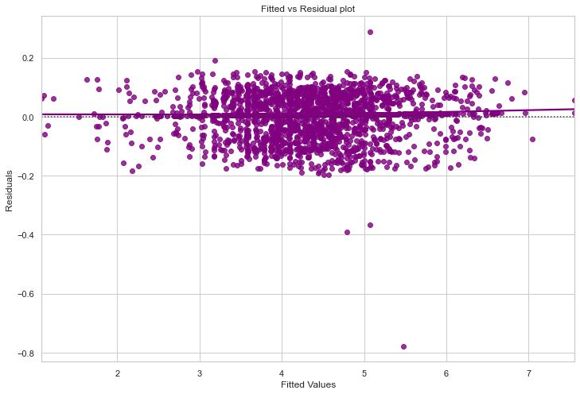

```python
# let's plot the fitted values vs residuals

sns.residplot(
    data=df_pred, x="Actual Values", y="Residuals", color="purple", lowess=True
)
plt.xlabel("Fitted Values")
plt.ylabel("Residuals")
plt.title("Fitted vs Residual plot")
plt.show()
```

### check the normality

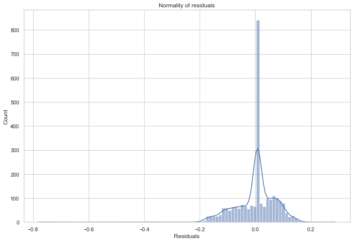

```python
sns.histplot(df_pred["Residuals"], kde=True)
plt.title("Normality of residuals")
plt.show()
```

- The histogram of residuals does not have a bell shape.

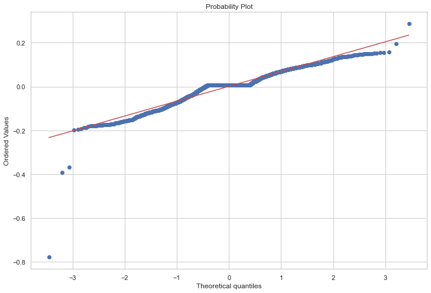

```python
import pylab
import scipy.stats as stats
stats.probplot(df_pred["Residuals"],dist="norm",plot=pylab)
plt.show();
```

- The residuals more or less follow a straight line but in my opinion, it is not completely straight

```python
stats.shapiro(df_pred["Residuals"])
```

```
ShapiroResult(statistic=0.9292929768562317, pvalue=7.892092747268215e-33)
```

**Null hypothesis: Residuals are normally distributed**

**Alternate hypothesis: Residuals are not normally distributed**

- Since p-value < 0.05, the residuals are not normal as per the Shapiro-Wilk test.

### Homoscedasticity test

```python
import statsmodels.stats.api as sms
from statsmodels.compat import lzip
name = ["F statistic", "p-value"]
test = sms.het_goldfeldquandt(df_pred["Residuals"] , x_train4)
lzip(name, test)
```

```
[('F statistic', 0.9683741300725583), ('p-value', 0.7143144159387494)]
```

Since p-value > 0.05, we can say that the residuals are homoscedastic. So, **this assumption is satisfied.**

### All the assumptions of linear regression have been checked but two tests for checking the normality are not satisfied. since I did set the model on `log transformation` for `y` I believe we should apply non-parametric tests e.g. chi-square in place of correlation. Although I believe there should be some complicated transformations to solve this problem which I don't know them yet...

## Final Model Summary

```python
olsmodel_final = sm.OLS(y_train, x_train4).fit()
print(olsmodel_final.summary())
```

```
                            OLS Regression Results
==============================================================================
Dep. Variable:         log_used_price   R-squared:                       0.990
Model:                            OLS   Adj. R-squared:                  0.990
Method:                 Least Squares   F-statistic:                 3.535e+04
Date:                Wed, 18 Aug 2021   Prob (F-statistic):               0.00
Time:                        14:35:35   Log-Likelihood:                 2665.4
No. Observations:                2499   AIC:                            -5315.
Df Residuals:                    2491   BIC:                            -5268.
Df Model:                           7
Covariance Type:            nonrobust
========================================================================================
                           coef    std err          t      P>|t|      [0.025      0.975]
----------------------------------------------------------------------------------------
const                   -0.1337      0.015     -9.102      0.000      -0.162      -0.105
screen_size              0.0017      0.000      3.519      0.000       0.001       0.003
int_memory               0.0001   5.16e-05      2.621      0.009     3.4e-05       0.000
days_used               -0.0011   8.15e-06   -138.421      0.000      -0.001      -0.001
log_new_price            0.9977      0.003    369.813      0.000       0.992       1.003
brand_name_Gionee       -0.0372      0.013     -2.788      0.005      -0.063      -0.011
brand_name_Lenovo       -0.0238      0.008     -3.019      0.003      -0.039      -0.008
brand_name_Panasonic    -0.0310      0.015     -2.116      0.034      -0.060      -0.002
==============================================================================
Omnibus:                      307.041   Durbin-Watson:                   2.062
Prob(Omnibus):                  0.000   Jarque-Bera (JB):              832.939
Skew:                          -0.669   Prob(JB):                    1.35e-181
Kurtosis:                       5.492   Cond. No.                     6.45e+03
==============================================================================

Notes:
[1] Standard Errors assume that the covariance matrix of the errors is correctly specified.
[2] The condition number is large, 6.45e+03. This might indicate that there are
strong multicollinearity or other numerical problems.
```

##### I think price of used cell phones is much related to the price of new cell phones .

```python
# checking model performance on train set (seen 70% data)
print("Training Performance\n")
olsmod2_train_perf = model_performance_regression(olsmod2, x_train4, y_train)
olsmod2_train_perf
```

```
Training Performance
```

|  | RMSE | MAE | R-squared | Adj. R-squared | MAPE | variance_score |
| --- | --- | --- | --- | --- | --- | --- |
| 0 | 11.473 | 7.136 | 0.991 | 0.991 | 0.070 | 0.991 |

```python
# checking model performance on test set (seen 30% data)
print("Test Performance\n")
olsmod2_test_perf = model_performance_regression(olsmod2, x_test4, y_test)
olsmod2_test_perf
```

```
Test Performance
```

|  | RMSE | MAE | R-squared | Adj. R-squared | MAPE | variance_score |
| --- | --- | --- | --- | --- | --- | --- |
| 0 | 11.487 | 7.322 | 0.990 | 0.990 | 0.071 | 0.990 |

The model is able to explain ~99% of the variation in the data, which is very good.

The train and test RMSE and MAE are low and comparable. So, our model is not suffering from overfitting.

The MAPE on the test set suggests we can predict within 7% of the used cell phone price.

Hence, we can conclude the model olsmod2 is good for prediction as well as inference purposes.